# Lecture 2: CRS - Homework

Tyler Hoecker

## Setup

Load general packages, set filepath for data files.

```r
library (tidyverse)
library(rgdal)
data_path = "/Users/tylerhoecker/GitHub/Zoo955_fork/Data/"
```

## 1) Download the LTER lake shapefiles from the LTER database. Map Lake Mendota. Add a point for the location of the CFL.

### Using `library(sp)` and `library(raster)`

Load packages for this section.

```r
library(sp)
library(raster)
```

Download North Temperatre Lakes LTER study lakes spatial data from a URL and save it to ‘Data’ directory.

```r
download_link <- 'https://lter.limnology.wisc.edu/file/11669/download?token=tWhRExjmwpMK9caKoMd2VcgKmFln3dKHVTC0mwUBvqg'
temp <- tempfile()
download.file(download_link,temp)
unzip(temp, exdir = paste0(data_path,'NTL_LTER_Yahara_Lakes'))
unlink(temp)
```

Load shapefile.

```r
yahara_lakes <- readOGR(dsn = paste0(data_path,'NTL_LTER_Yahara_Lakes'), layer = "yld_study_lakes")
```

Extract just Lake Mendota and transform CRS to WGS84.

```r
lake_mendota <-
  yahara_lakes[yahara_lakes$SHAIDNAME == 'Lake Mendota',] %>%
  spTransform(., CRS("+init=epsg:4326 +proj=longlat +datum=WGS84 +no_defs +ellps=WGS84 +towgs84=0,0,0"))
```

Create a point for the CFL (looked up using Google Maps), and define its CRS to be the same as `lake_mendota`

```r
cfl_pt <-
  data.frame(x = -89.402923, y = 43.077269) %>%
  SpatialPoints() %>%
  `crs<-` (crs(lake_mendota))
```

Plot the lake shapefile and the CFL point

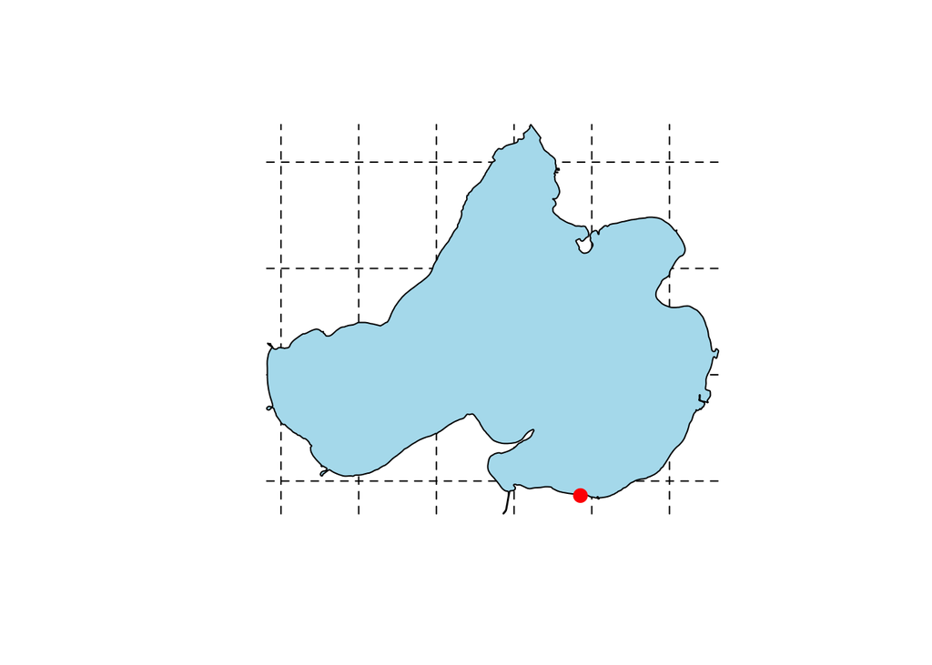

```r
plot(gridlines(lake_mendota), lty=2)
plot(lake_mendota, col = 'lightblue2', add=TRUE)
plot(cfl_pt, pch = 20, col = 'red', cex = 2, add = TRUE)
```

### Or, do the same thing using `library(sf)`

I like the sf package because it plays nicely with the tidyverse, and treats spatial objects more like regular dataframes.

Load packages for this section.

```r
library(sf)
```

Read in `yld_study_lakes.shp`, transform CRS to WGS84, and filter out only Lake Mendota.

```r
lake_mendota_sf <-
  st_read(dsn = paste0(data_path,'NTL_LTER_Yahara_Lakes/yld_study_lakes.shp')) %>%
  st_transform(crs = c("+init=epsg:4326 +proj=longlat +datum=WGS84 +no_defs +ellps=WGS84 +towgs84=0,0,0")) %>%
  filter(SHAIDNAME == 'Lake Mendota')
```

Make a new sf object for the CFL.

```r
cfl_sf <- data.frame(x = -89.402923, y = 43.077269) %>%
  st_as_sf(coords = c("x", "y"), crs = st_crs(lake_mendota_sf))
```

Plot them both.

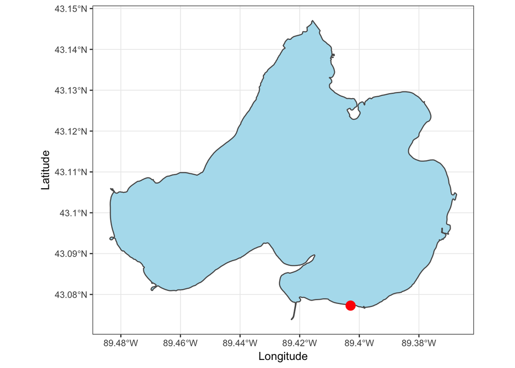

```r
ggplot() +
  geom_sf(data = lake_mendota_sf, fill = 'lightblue2') +
  geom_sf(data = cfl_sf, colour = "red", size = 4) +
  labs(x = 'Longitude', y = 'Latitude') +
  theme_bw()
```

Or, plot Lake Mendota, and use `annotate` to add the CFL “by hand”.

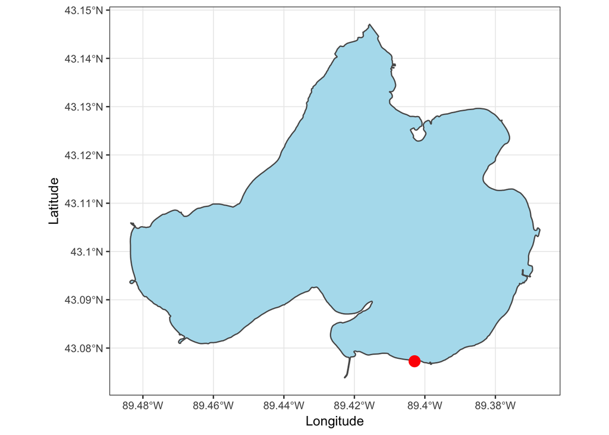

```r
ggplot() +
  geom_sf(data = lake_mendota_sf, fill = 'lightblue2') +
  annotate("point", x = -89.402923, y = 43.077269, colour = "red", size = 4) +
  labs(x = 'Longitude', y = 'Latitude') +
  theme_bw()
```

## 2) Download the National Land Cover (NLCD) dataset for 2011. Load it into R. What is the CRS?

Download NLCD dataset from URL.

```r
download_link <- 'http://www.landfire.gov/bulk/downloadfile.php?TYPE=nlcd2001v2&FNAME=nlcd_2001_landcover_2011_edition_2014_10_10.zip'

temp <- tempfile()
#download.file(download_link,temp)
unzip(temp, exdir = 'Data/')
unlink(temp)
```

Load NLCD dataset, and view CRS.

```r
nlcd <- raster(paste0(data_path,'NLCD/nlcd_2001_landcover_2011_edition_2014_10_10.img'))

crs(nlcd)
```

```
## CRS arguments:
##  +proj=aea +lat_1=29.5 +lat_2=45.5 +lat_0=23 +lon_0=-96 +x_0=0
## +y_0=0 +ellps=GRS80 +towgs84=0,0,0,0,0,0,0 +units=m +no_defs
```

# 3) What’s the best way to check that CRS of two objects are identical?

The simplest way I can think of is to compare the proj4strings as character strings. If they are completely identical, the boolean comparison will be true: `as.character( crs(object1) ) == as.character( crs(object2) )`.

Here are some functions that could be handy:

```r
crsTest <- function(object1, object2){
  if(as.character(crs(object1)) == as.character(crs(object2))){
    print("You're in luck, the CRS's are identical!")
} else {
    print("CRS's not equal, try again.")}
}

crsTest(lake_mendota,nlcd)
```

```
## [1] "CRS's not equal, try again."
```

For sf objects:

```r
st_crsTest <- function(object1, object2){
  if(as.character(st_crs(object1)[2]) == as.character(st_crs(object2)[2])){
    print("You're in luck, the CRS's are identical!")
} else {
    print("CRS's not equal, try again.")}
}

st_crsTest(lake_mendota_sf,cfl_sf)
```

```
## [1] "You're in luck, the CRS's are identical!"
```

### Turns out there’s already a function for this in sp… but it’s messages are pretty boring :)

```r
identicalCRS(lake_mendota,nlcd)
```

```
## [1] FALSE
```